# examples_0204

On the right triangle below, find the length of the missing side.

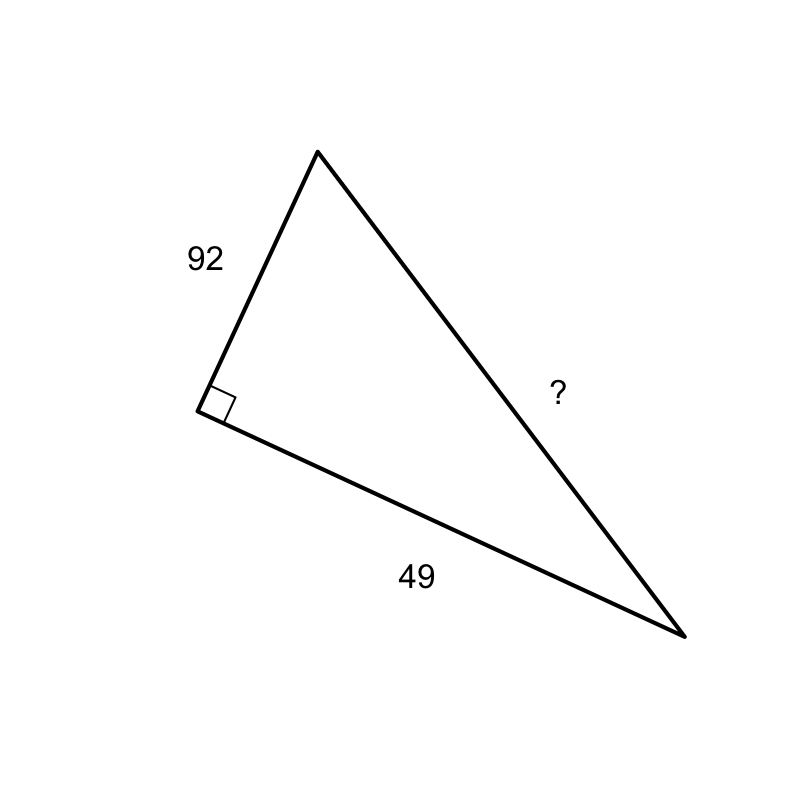

The tolerance is $\pm 0.1$.

Use pythagorean theorem.

$$a=49$$
$$b=92$$

$a^2+b^2=c^2$

$$c = \sqrt{a^2+b^2}$$

$$c = \sqrt{{49}^2+{92}^2}$$

$$c\approx 104.24$$

On the right triangle below, find the length of the missing side.

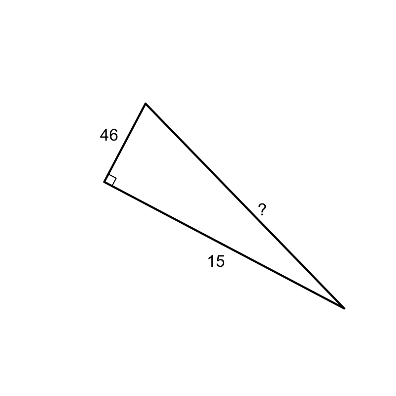

The tolerance is $\pm 0.1$.

Use pythagorean theorem.

$$a=15$$
$$b=46$$

$a^2+b^2=c^2$

$$c = \sqrt{a^2+b^2}$$

$$c = \sqrt{{15}^2+{46}^2}$$

$$c\approx 48.38$$

On the right triangle below, find the length of the missing side.

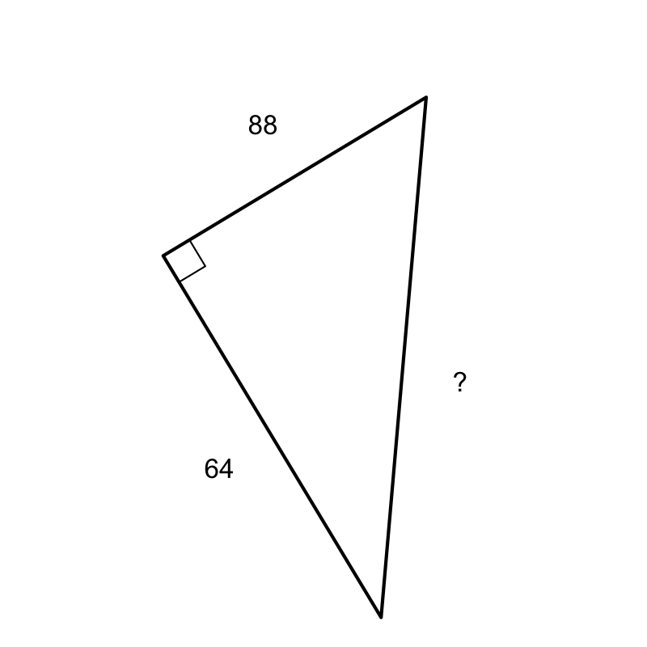

The tolerance is $\pm 0.1$.

Use pythagorean theorem.

$$a=64$$
$$b=88$$

$a^2+b^2=c^2$

$$c = \sqrt{a^2+b^2}$$

$$c = \sqrt{{64}^2+{88}^2}$$

$$c\approx 108.81$$

On the right triangle below, find the length of the missing side.

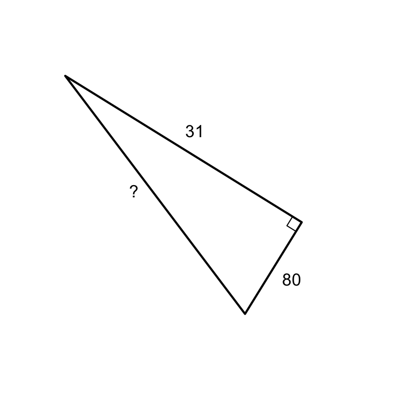

The tolerance is $\pm 0.1$.

Use pythagorean theorem.

$$a=31$$
$$b=80$$

$a^2+b^2=c^2$

$$c = \sqrt{a^2+b^2}$$

$$c = \sqrt{{31}^2+{80}^2}$$

$$c\approx 85.80$$

On the right triangle below, find the length of the missing side.

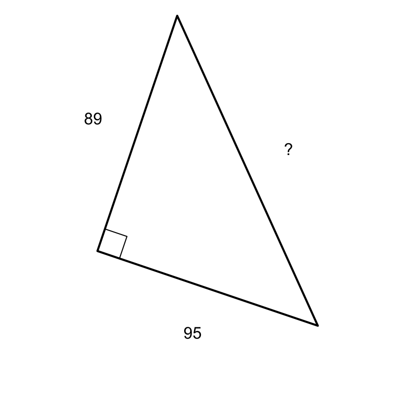

The tolerance is $\pm 0.1$.

Use pythagorean theorem.

$$a=95$$
$$b=89$$

$a^2+b^2=c^2$

$$c = \sqrt{a^2+b^2}$$

$$c = \sqrt{{95}^2+{89}^2}$$

$$c\approx 130.18$$

On the right triangle below, find the length of the missing side.

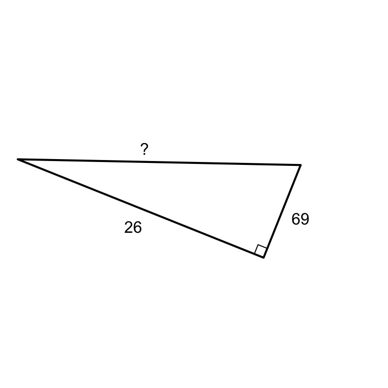

The tolerance is $\pm 0.1$.

Use pythagorean theorem.

$$a=26$$
$$b=69$$

$a^2+b^2=c^2$

$$c = \sqrt{a^2+b^2}$$

$$c = \sqrt{{26}^2+{69}^2}$$

$$c\approx 73.74$$

On the right triangle below, find the length of the missing side.

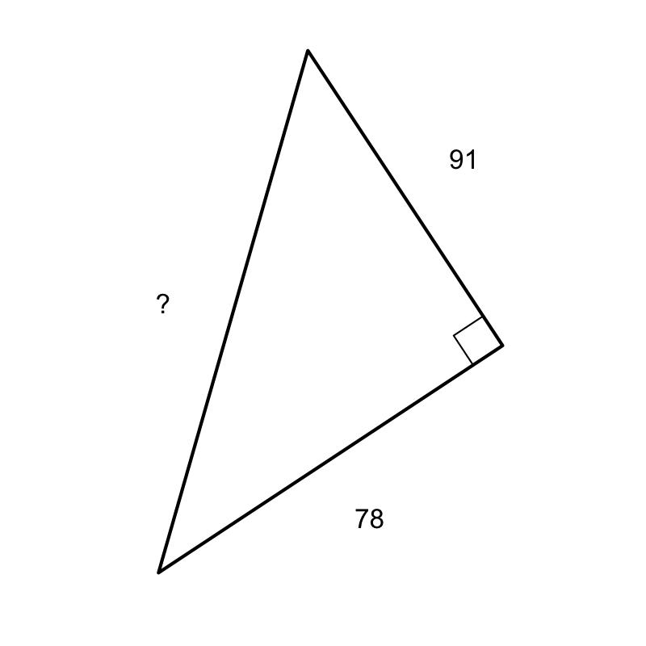

The tolerance is $\pm 0.1$.

Use pythagorean theorem.

$$a=91$$
$$b=78$$

$a^2+b^2=c^2$

$$c = \sqrt{a^2+b^2}$$

$$c = \sqrt{{91}^2+{78}^2}$$

$$c\approx 119.85$$

On the right triangle below, find the length of the missing side.

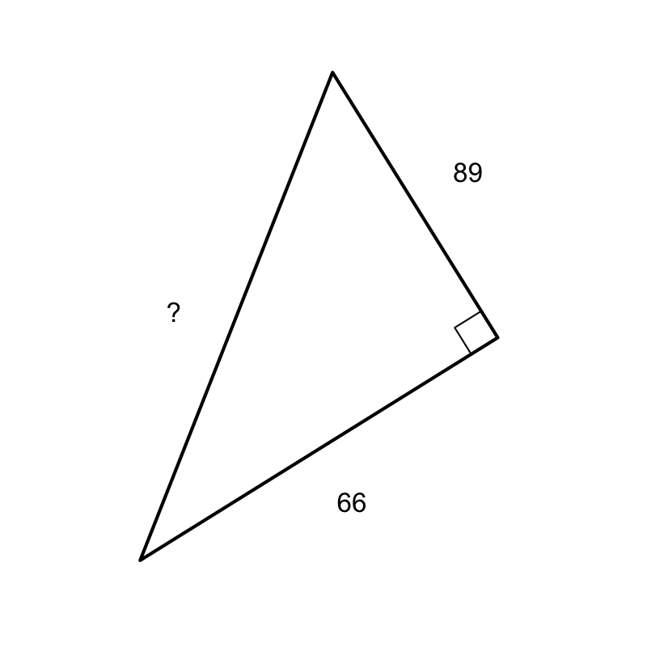

The tolerance is $\pm 0.1$.

Use pythagorean theorem.

$$a=89$$
$$b=66$$

$a^2+b^2=c^2$

$$c = \sqrt{a^2+b^2}$$

$$c = \sqrt{{89}^2+{66}^2}$$

$$c\approx 110.80$$

On the right triangle below, find the length of the missing side.

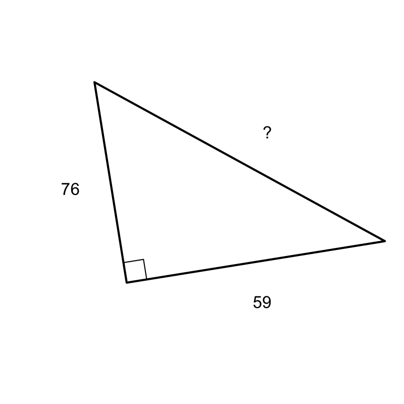

The tolerance is $\pm 0.1$.

Use pythagorean theorem.

$$a=59$$
$$b=76$$

$a^2+b^2=c^2$

$$c = \sqrt{a^2+b^2}$$

$$c = \sqrt{{59}^2+{76}^2}$$

$$c\approx 96.21$$

On the right triangle below, find the length of the missing side.

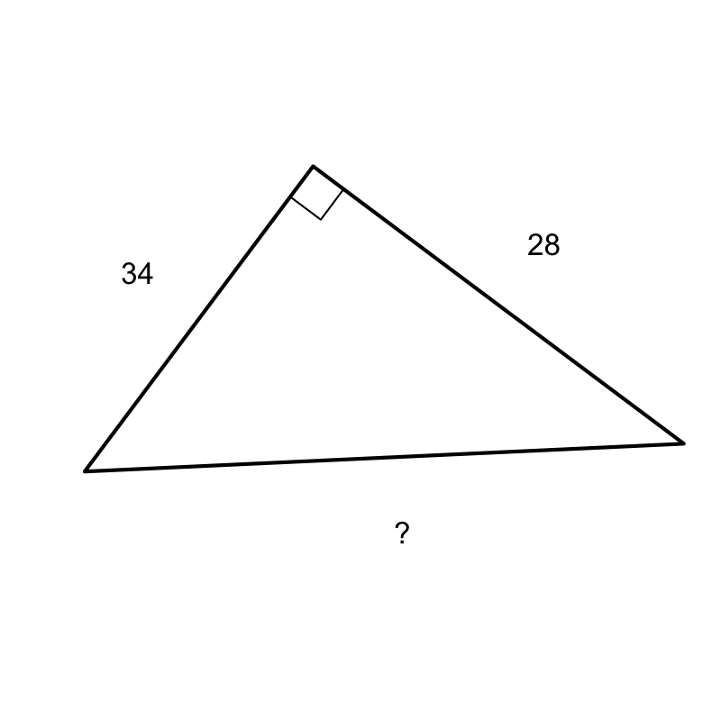

The tolerance is $\pm 0.1$.

Use pythagorean theorem.

$$a=28$$
$$b=34$$

$a^2+b^2=c^2$

$$c = \sqrt{a^2+b^2}$$

$$c = \sqrt{{28}^2+{34}^2}$$

$$c\approx 44.05$$

On the right triangle below, find the length of the missing side.

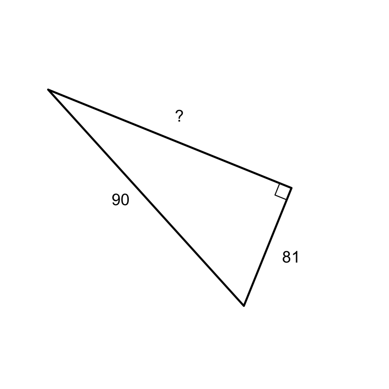

The tolerance is $\pm 0.1$.

Use pythagorean theorem.

$$a=81$$
$$c=90$$

$a^2+b^2=c^2$

$b^2=c^2-a^2$

$$b = \sqrt{c^2-a^2}$$

$$b = \sqrt{{90}^2-{81}^2}$$

$$b\approx 39.23$$

On the right triangle below, find the length of the missing side.

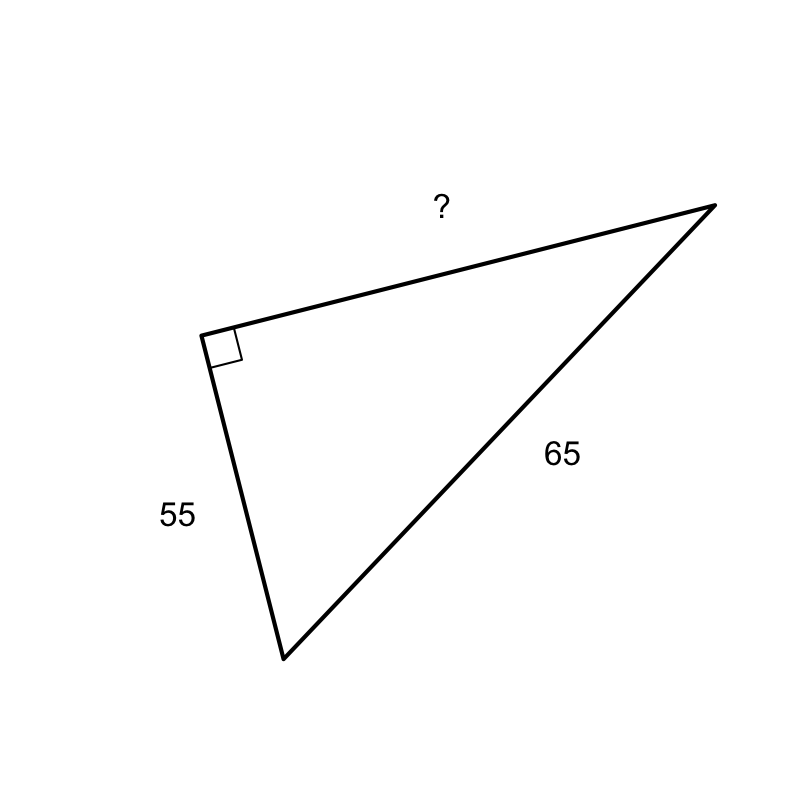

The tolerance is $\pm 0.1$.

Use pythagorean theorem.

$$a=55$$
$$c=65$$

$a^2+b^2=c^2$

$b^2=c^2-a^2$

$$b = \sqrt{c^2-a^2}$$

$$b = \sqrt{{65}^2-{55}^2}$$

$$b\approx 34.64$$

On the right triangle below, find the length of the missing side.

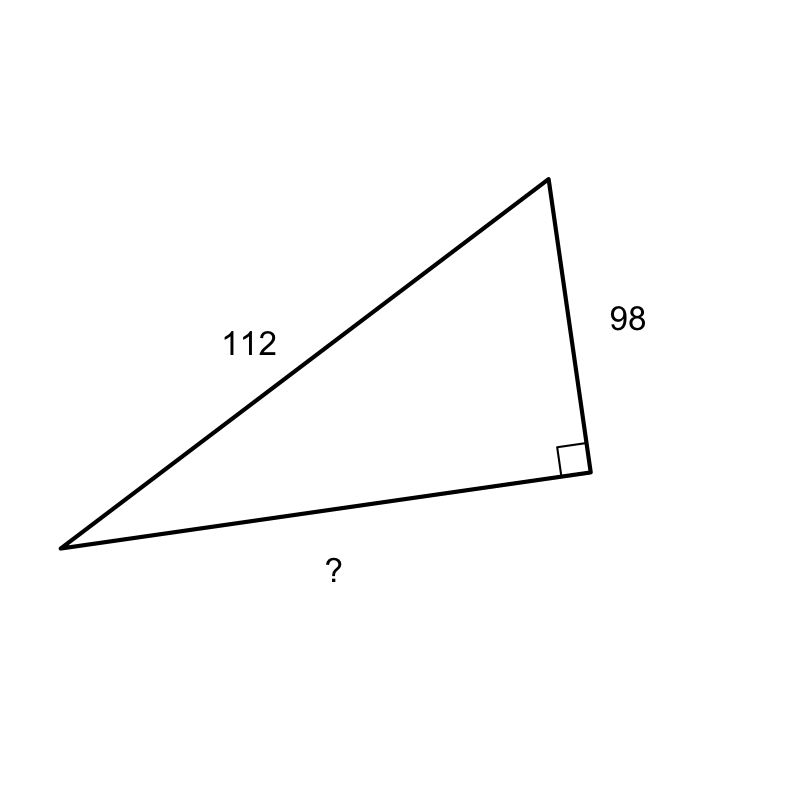

The tolerance is $\pm 0.1$.

Use pythagorean theorem.

$$a=98$$
$$c=112$$

$a^2+b^2=c^2$

$b^2=c^2-a^2$

$$b = \sqrt{c^2-a^2}$$

$$b = \sqrt{{112}^2-{98}^2}$$

$$b\approx 54.22$$

On the right triangle below, find the length of the missing side.

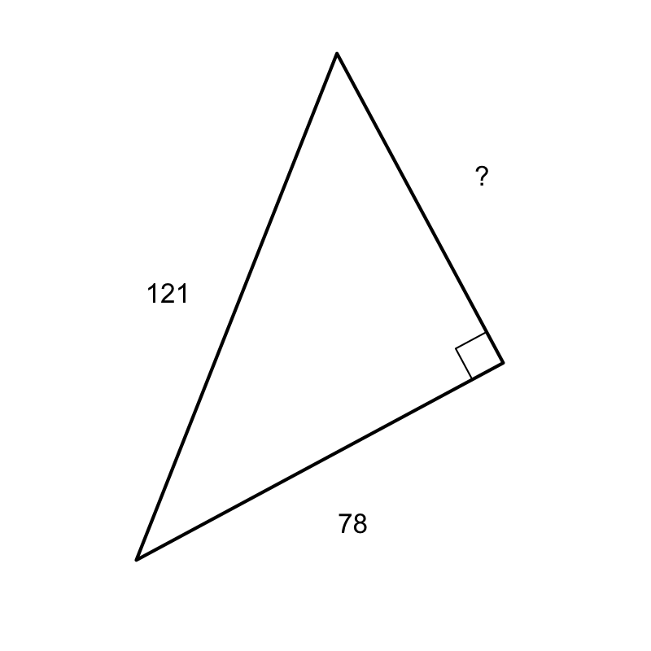

The tolerance is $\pm 0.1$.

Use pythagorean theorem.

$$a=78$$
$$c=121$$

$a^2+b^2=c^2$

$b^2=c^2-a^2$

$$b = \sqrt{c^2-a^2}$$

$$b = \sqrt{{121}^2-{78}^2}$$

$$b\approx 92.50$$

On the right triangle below, find the length of the missing side.

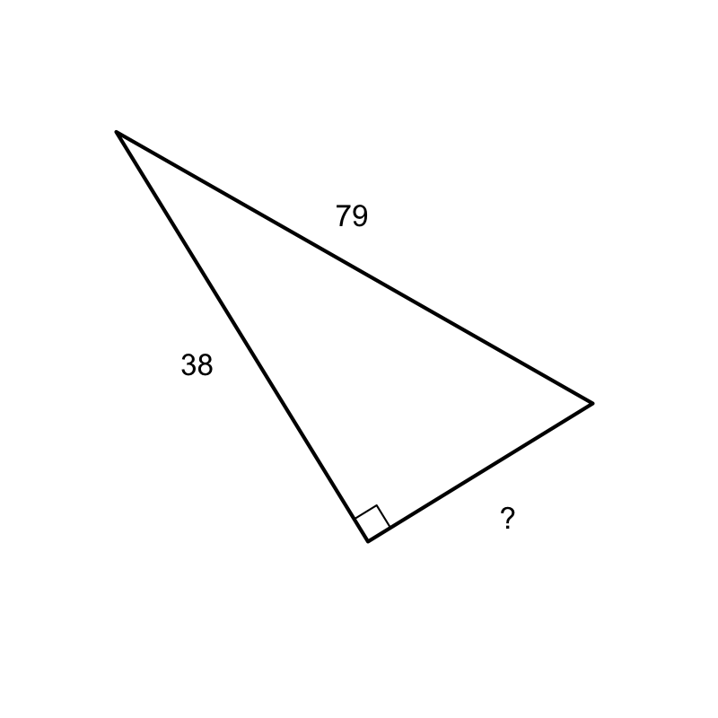

The tolerance is $\pm 0.1$.

Use pythagorean theorem.

$$a=38$$
$$c=79$$

$a^2+b^2=c^2$

$b^2=c^2-a^2$

$$b = \sqrt{c^2-a^2}$$

$$b = \sqrt{{79}^2-{38}^2}$$

$$b\approx 69.26$$

On the right triangle below, find the length of the missing side.

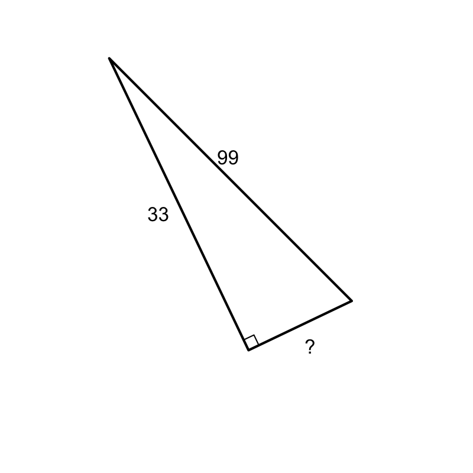

The tolerance is $\pm 0.1$.

Use pythagorean theorem.

$$a=33$$
$$c=99$$

$a^2+b^2=c^2$

$b^2=c^2-a^2$

$$b = \sqrt{c^2-a^2}$$

$$b = \sqrt{{99}^2-{33}^2}$$

$$b\approx 93.34$$

On the right triangle below, find the length of the missing side.

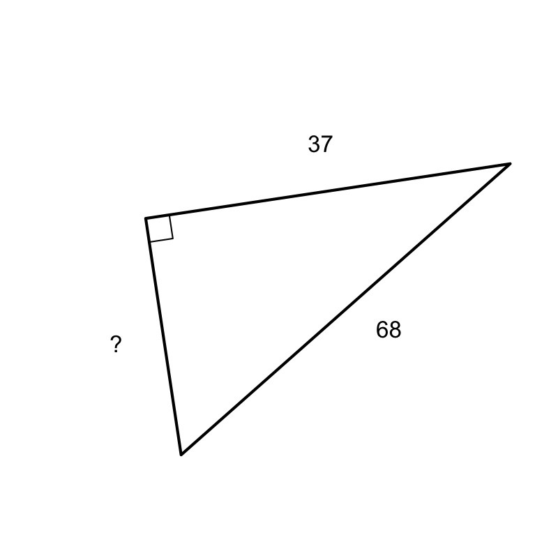

The tolerance is $\pm 0.1$.

Use pythagorean theorem.

$$a=37$$
$$c=68$$

$a^2+b^2=c^2$

$b^2=c^2-a^2$

$$b = \sqrt{c^2-a^2}$$

$$b = \sqrt{{68}^2-{37}^2}$$

$$b\approx 57.05$$

On the right triangle below, find the length of the missing side.

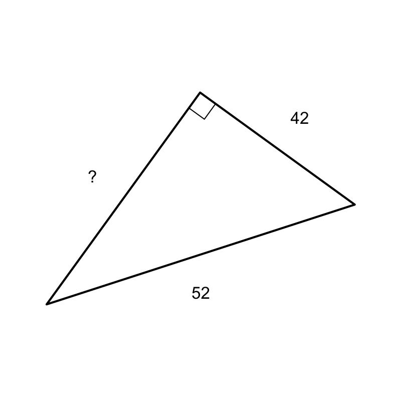

The tolerance is $\pm 0.1$.

Use pythagorean theorem.

$$a=42$$
$$c=52$$

$a^2+b^2=c^2$

$b^2=c^2-a^2$

$$b = \sqrt{c^2-a^2}$$

$$b = \sqrt{{52}^2-{42}^2}$$

$$b\approx 30.66$$

On the right triangle below, find the length of the missing side.

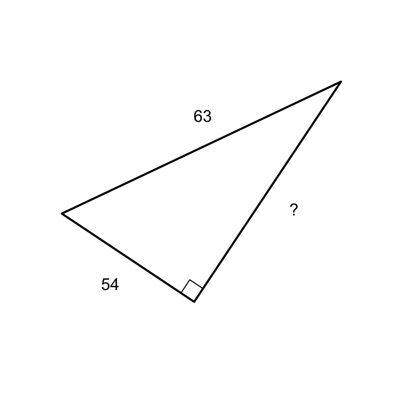

The tolerance is $\pm 0.1$.

Use pythagorean theorem.

$$a=54$$
$$c=63$$

$a^2+b^2=c^2$

$b^2=c^2-a^2$

$$b = \sqrt{c^2-a^2}$$

$$b = \sqrt{{63}^2-{54}^2}$$

$$b\approx 32.45$$

On the right triangle below, find the length of the missing side.

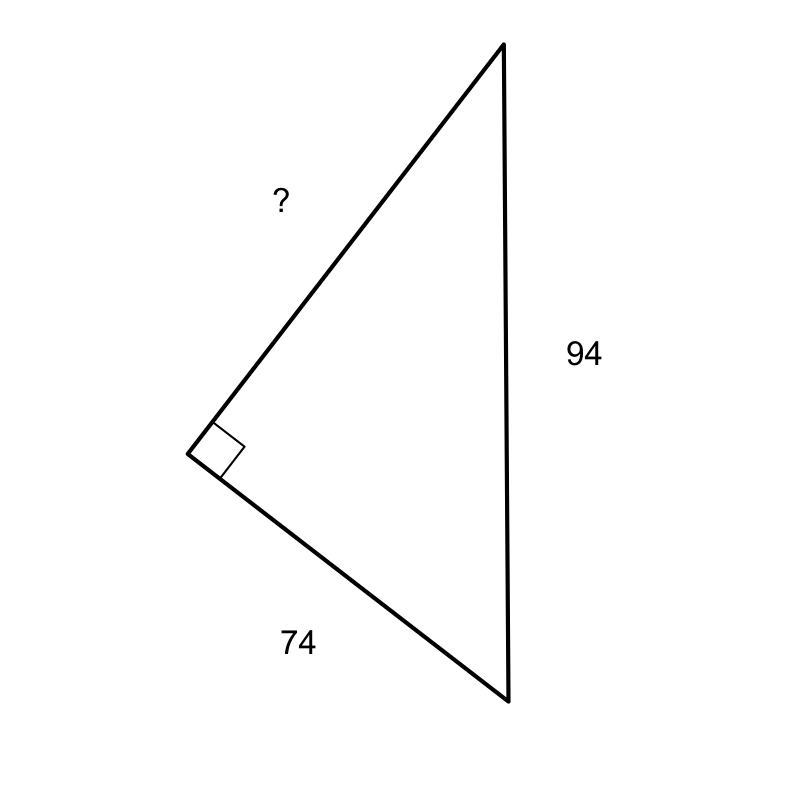

The tolerance is $\pm 0.1$.

Use pythagorean theorem.

$$a=74$$
$$c=94$$

$a^2+b^2=c^2$

$b^2=c^2-a^2$

$$b = \sqrt{c^2-a^2}$$

$$b = \sqrt{{94}^2-{74}^2}$$

$$b\approx 57.97$$